# Modeling and prediction for movies

## Setup

This project details our analysis of the movie dataset that contains information from [Rotten Tomatos](https://www.rottentomatoes.com/) and [IMDB](http://www.imdb.com/) for a random sample of movies. The purpose of this project is to develop a multiple linear regression model to understand what attributes make a movie popular. In the meantime, learning something new about movies.

### Load packages

```r
library(ggplot2)
library(dplyr)
library(statsr)
library(gridExtra)
library(corrplot)
```

### Load data

```r
load("movies.Rdata")
```

## Part 1: Data

The data set is comprised of 651 randomly sampled movies produced and released before 2016, each row in the dataset is a movie and each column is a characteristic of a movie. Therefore, the data should allow us to generalize to the population of interest. However, there is no causation can be established because random assignment is not used in this study. In addition, potential biases are associated with non-voting or non_rating because the voting and rating are voluntary on IMDB and Rotten Tomatos website.

From common sense, we realized that many of the variables are irrelevant to the purpose of identifying the popularity of a movie. As such, we select the following variables to start our analysis.

- title_type: Type of movie (Documentary, Feature Film, TV Movie)
- genre: Genre of movie (Action & Adventure, Comedy, Documentary, Drama, Horror, Mystery & Suspense, Other)
- runtime: Runtime of movie (in minutes)
- imdb_rating: Rating on IMDB
- imdb_num_votes: Number of votes on IMDB
- critics_rating: Categorical variable for critics rating on Rotten Tomatoes (Certified Fresh, Fresh, Rotten)
- critics_score: Critics score on Rotten Tomatoes
- audience_rating: Categorical variable for audience rating on Rotten Tomatoes (Spilled, Upright)
- audience_score: Audience score on Rotten Tomatoes
- best_pic_win: Whether or not the movie won a best picture Oscar (no, yes)
- best_actor_win: Whether or not one of the main actors in the movie ever won an Oscar (no, yes) - note that this is not necessarily whether the actor won an Oscar for their role in the given movie
- best_actress win: Whether or not one of the main actresses in the movie ever won an Oscar (no, yes) - not that this is not necessarily whether the actresses won an Oscar for their role in the given movie
- best_dir_win: Whether or not the director of the movie ever won an Oscar (no, yes) - not that this is not necessarily whether the director won an Oscar for the given movie

## Part 2: Research question

Is a movie’s popularity, as measured by audience score, related to the type of movie, genre, runtime, imdb rating, imdb number of votes, critics rating, critics score, audience rating, Oscar awards obtained (actor, actress, director and picture)? Being able to answer this question will help us to predict a movie’s popularity.

## Part 3: Exploratory data analysis and feature selection

Abstracting the data of the above potential predictors for the model.

```r
movies_new <- movies %>% select(title, title_type, genre, runtime, imdb_rating, imdb_num_votes, critics_rating, critics_score, audience_rating, audience_score, best_pic_win, best_actor_win, best_actress_win, best_dir_win)
```

Look at the structure of the data

```r
str(movies_new)
```

```
## Classes 'tbl_df', 'tbl' and 'data.frame':    651 obs. of  14 variables:
##  $ title           : chr  "Filly Brown" "The Dish" "Waiting for Guffman" "The Age of Innocence" ...
##  $ title_type      : Factor w/ 3 levels "Documentary",..: 2 2 2 2 2 1 2 2 1 2 ...
##  $ genre           : Factor w/ 11 levels "Action & Adventure",..: 6 6 4 6 7 5 6 6 5 6 ...
##  $ runtime         : num  80 101 84 139 90 78 142 93 88 119 ...
##  $ imdb_rating     : num  5.5 7.3 7.6 7.2 5.1 7.8 7.2 5.5 7.5 6.6 ...
##  $ imdb_num_votes  : int  899 12285 22381 35096 2386 333 5016 2272 880 12496 ...
##  $ critics_rating  : Factor w/ 3 levels "Certified Fresh",..: 3 1 1 1 3 2 3 3 2 1 ...
##  $ critics_score   : num  45 96 91 80 33 91 57 17 90 83 ...
##  $ audience_rating : Factor w/ 2 levels "Spilled","Upright": 2 2 2 2 1 2 2 1 2 2 ...
##  $ audience_score  : num  73 81 91 76 27 86 76 47 89 66 ...
##  $ best_pic_win    : Factor w/ 2 levels "no","yes": 1 1 1 1 1 1 1 1 1 1 ...
##  $ best_actor_win  : Factor w/ 2 levels "no","yes": 1 1 1 2 1 1 1 2 1 1 ...
##  $ best_actress_win: Factor w/ 2 levels "no","yes": 1 1 1 1 1 1 1 1 1 1 ...
##  $ best_dir_win    : Factor w/ 2 levels "no","yes": 1 1 1 2 1 1 1 1 1 1 ...
```

Summary statistics

```r
summary(movies_new)
```

```
##     title                  title_type                 genre
##  Length:651         Documentary : 55   Drama             :305
##  Class :character   Feature Film:591   Comedy            : 87
##  Mode  :character   TV Movie    :  5   Action & Adventure: 65
##                                        Mystery & Suspense: 59
##                                        Documentary       : 52
##                                        Horror            : 23
##                                        (Other)           : 60
##     runtime       imdb_rating    imdb_num_votes           critics_rating
##  Min.   : 39.0   Min.   :1.900   Min.   :   180   Certified Fresh:135
##  1st Qu.: 92.0   1st Qu.:5.900   1st Qu.:  4546   Fresh          :209
##  Median :103.0   Median :6.600   Median : 15116   Rotten         :307
##  Mean   :105.8   Mean   :6.493   Mean   : 57533
##  3rd Qu.:115.8   3rd Qu.:7.300   3rd Qu.: 58300
##  Max.   :267.0   Max.   :9.000   Max.   :893008
##  NA's   :1
##  critics_score    audience_rating audience_score  best_pic_win
##  Min.   :  1.00   Spilled:275     Min.   :11.00   no :644
##  1st Qu.: 33.00   Upright:376     1st Qu.:46.00   yes:  7
##  Median : 61.00                   Median :65.00
##  Mean   : 57.69                   Mean   :62.36
##  3rd Qu.: 83.00                   3rd Qu.:80.00
##  Max.   :100.00                   Max.   :97.00
##
##  best_actor_win best_actress_win best_dir_win
##  no :558        no :579          no :608
##  yes: 93        yes: 72          yes: 43
##
##
##
##
##
```

I find there is one missing value, and decide to drop it.

```r
movies_new <- na.omit(movies_new)
```

Part of this project is to use the model to predict a movie’s audience score and this movie should not be part of the data. Therefore, I split the data into traning and testing, and there is only one row in the test set.

```r
set.seed(2017)
split <- sample(seq_len(nrow(movies_new)), size = floor(0.999 * nrow(movies_new)))
train <- movies_new[split, ]
test <- movies_new[-split, ]
dim(train)
```

```
## [1] 649  14
```

```r
dim(test)
```

```
## [1]  1 14
```

### Histogram of Numeric variables

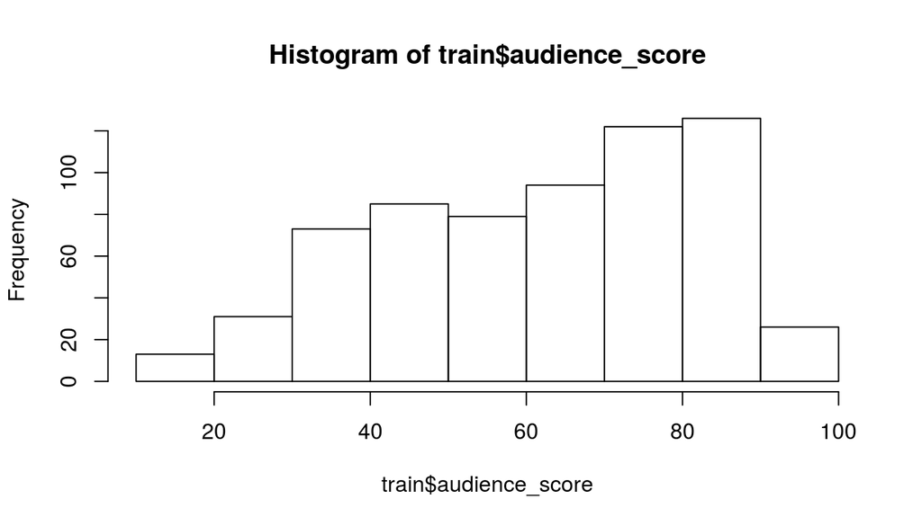

```r
hist(train$audience_score)
```

```r
summary(train$audience_score)
```

```
##    Min. 1st Qu.  Median    Mean 3rd Qu.    Max.
##    11.0    46.0    65.0    62.3    80.0    97.0
```

The median of our response variable - audience score distribution is 65; 25% of the movie in the training set have an audience score higher than 80; 25% of the movie in the training set have an audience score lower than 46; very few movie have an audience score lower than 20 or higher than 90 (i.e.Audience in the data are unlikey to give very low or very high score).

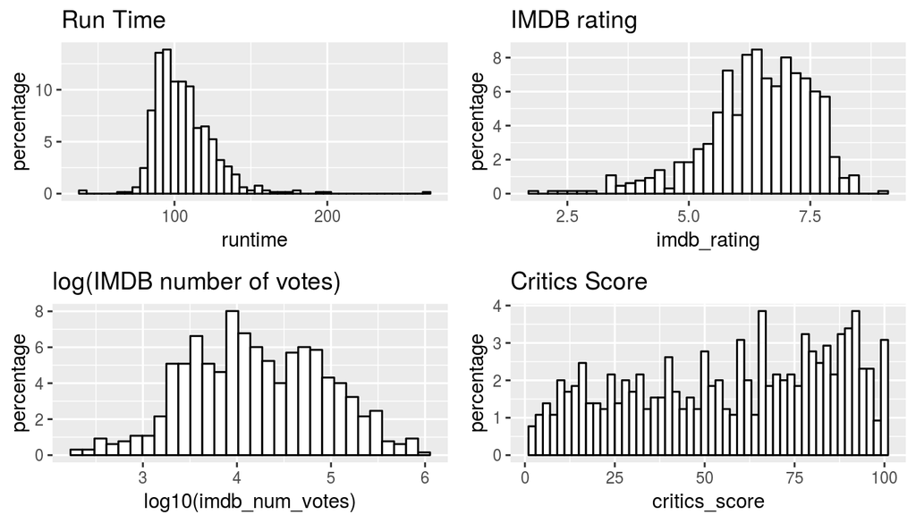

```r
p1 <- ggplot(aes(x=runtime), data=train) +
  geom_histogram(aes(y=100*(..count..)/sum(..count..)), color='black', fill='white', binwidth = 5) + ylab('percentage') + ggtitle('Run Time')
p2 <- ggplot(aes(x=imdb_rating), data=train) +
  geom_histogram(aes(y=100*(..count..)/sum(..count..)), color='black', fill='white', binwidth = 0.2) + ylab('percentage') + ggtitle('IMDB rating')
p3 <- ggplot(aes(x=log10(imdb_num_votes)), data=train) +
  geom_histogram(aes(y=100*(..count..)/sum(..count..)), color='black', fill='white') + ylab('percentage') + ggtitle('log(IMDB number of votes)')
p4 <- ggplot(aes(x=critics_score), data=train) +
  geom_histogram(aes(y=100*(..count..)/sum(..count..)), color='black', fill='white', binwidth = 2) + ylab('percentage') + ggtitle('Critics Score')
grid.arrange(p1, p2, p3, p4, ncol=2)
```

Regression analysis: Run time, IMDB rating, log(IMDB number of votes) and Critics Scores all have reasonable broad distribution, therefore, they will be considered for the regression analysis.

### Bar plot of categorical variables

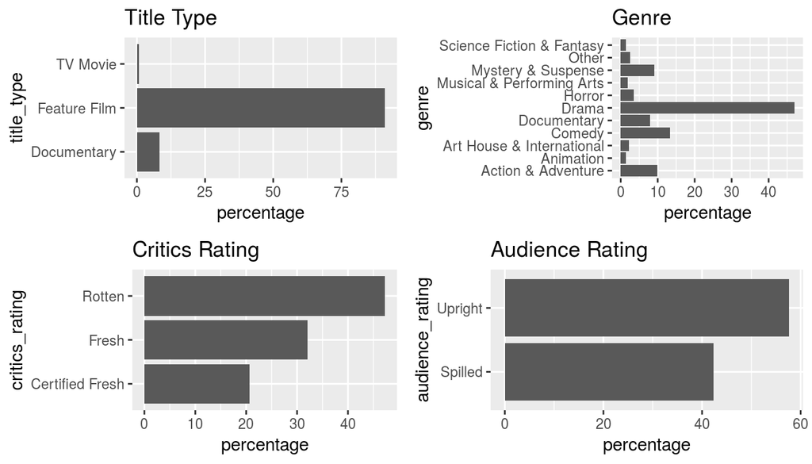

```r
p1 <- ggplot(aes(x=title_type), data=train) + geom_bar(aes(y=100*(..count..)/sum(..count..))) + ylab('percentage') +
  ggtitle('Title Type') + coord_flip()
p2 <- ggplot(aes(x=genre), data=train) + geom_bar(aes(y=100*(..count..)/sum(..count..))) + ylab('percentage') +
  ggtitle('Genre') + coord_flip()
p3 <- ggplot(aes(x=critics_rating), data=train) + geom_bar(aes(y=100*(..count..)/sum(..count..))) + ylab('percentage') +
  ggtitle('Critics Rating') + coord_flip()
p4 <- ggplot(aes(x=audience_rating), data=train) + geom_bar(aes(y=100*(..count..)/sum(..count..))) + ylab('percentage') +
  ggtitle('Audience Rating') + coord_flip()
grid.arrange(p1, p2, p3, p4, ncol=2)
```

### Correlation between numerical variables

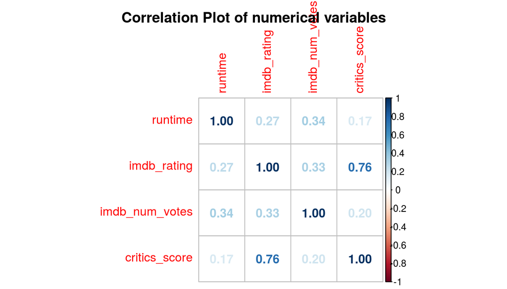

```r
vars <- names(train) %in% c('runtime', 'imdb_rating', 'imdb_num_votes', 'critics_score')
selected_train <- train[vars]
corr.matrix <- cor(selected_train)
corrplot(corr.matrix, main="\n\nCorrelation Plot of numerical variables", method="number")
```

Two predictors - critics score and imdb rating are highly correlated at 0.76 (collinearity), therefore, One of them will be removed from the model, I decided to remove critics score.

### Correlation between categorical variables and audience score

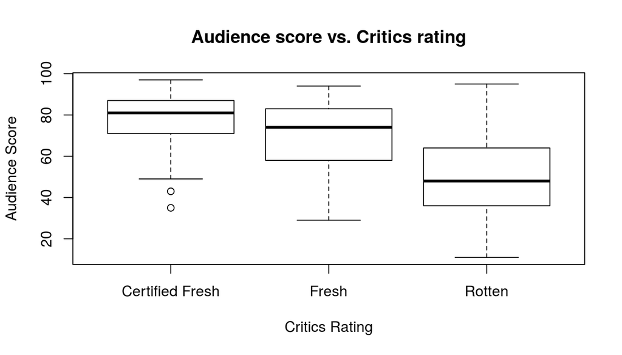

```r
boxplot(audience_score~critics_rating, data=train, main='Audience score vs. Critics rating', xlab='Critics Rating', ylab='Audience Score')
```

```r
by(train$audience_score, train$critics_rating, summary)
```

```
## train$critics_rating: Certified Fresh
##    Min. 1st Qu.  Median    Mean 3rd Qu.    Max.
##   35.00   71.00   81.00   79.26   87.00   97.00
## --------------------------------------------------------
## train$critics_rating: Fresh
##    Min. 1st Qu.  Median    Mean 3rd Qu.    Max.
##   29.00   58.00   74.00   69.96   83.00   94.00
## --------------------------------------------------------
## train$critics_rating: Rotten
##    Min. 1st Qu.  Median    Mean 3rd Qu.    Max.
##    11.0    36.0    48.0    49.7    64.0    95.0
```

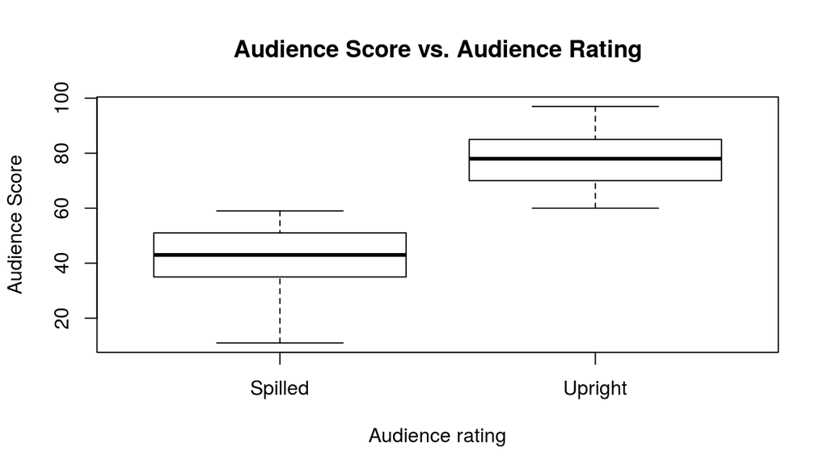

```r
boxplot(audience_score~audience_rating, data=train, main='Audience Score vs. Audience Rating', xlab='Audience rating', ylab='Audience Score')
```

```r
by(train$audience_score, train$audience_rating, summary)
```

```
## train$audience_rating: Spilled
##    Min. 1st Qu.  Median    Mean 3rd Qu.    Max.
##   11.00   35.00   43.00   41.93   51.00   59.00
## --------------------------------------------------------
## train$audience_rating: Upright
##    Min. 1st Qu.  Median    Mean 3rd Qu.    Max.
##   60.00   70.00   78.00   77.27   85.00   97.00
```

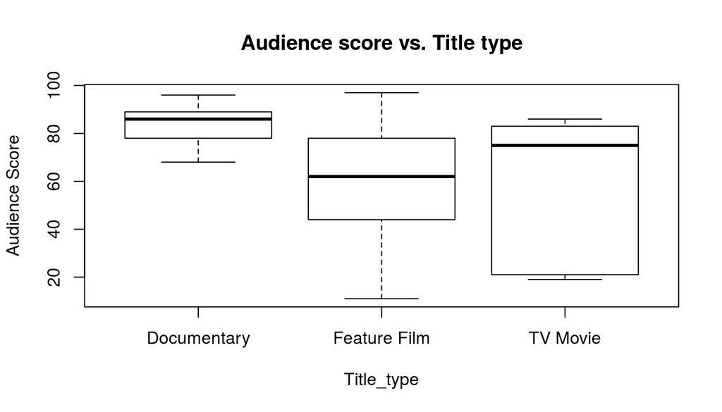

```r
boxplot(audience_score~title_type, data=train, main='Audience score vs. Title type', xlab='Title_type', ylab='Audience Score')
```

```r
by(train$audience_score, train$title_type, summary)
```

```
## train$title_type: Documentary
##    Min. 1st Qu.  Median    Mean 3rd Qu.    Max.
##   68.00   78.00   86.00   83.46   89.00   96.00
## --------------------------------------------------------
## train$title_type: Feature Film
##    Min. 1st Qu.  Median    Mean 3rd Qu.    Max.
##   11.00   44.25   62.00   60.41   78.00   97.00
## --------------------------------------------------------
## train$title_type: TV Movie
##    Min. 1st Qu.  Median    Mean 3rd Qu.    Max.
##    19.0    21.0    75.0    56.8    83.0    86.0
```

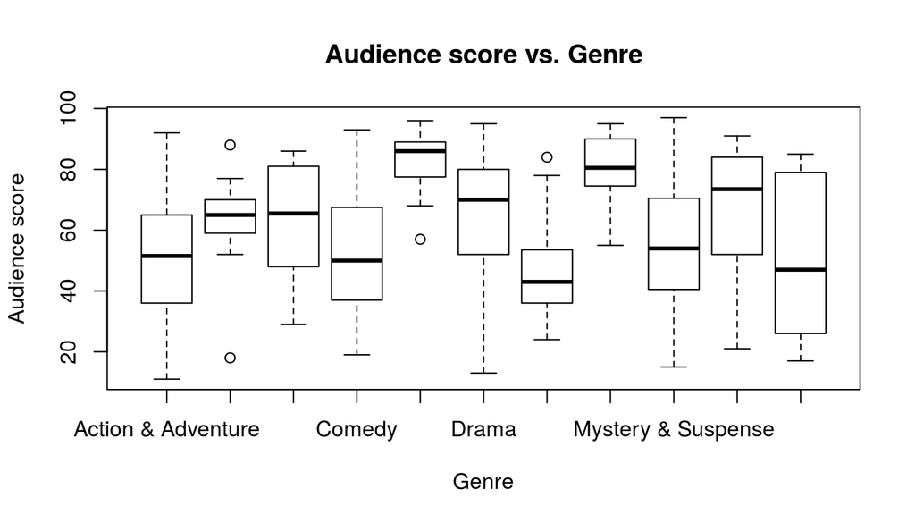

```r
boxplot(audience_score~genre, data=train, main='Audience score vs. Genre', xlab='Genre', ylab='Audience score')
```

```r
by(train$audience_score, train$genre, summary)
```

```
## train$genre: Action & Adventure
##    Min. 1st Qu.  Median    Mean 3rd Qu.    Max.
##   11.00   36.50   51.50   53.16   65.00   92.00
## --------------------------------------------------------
## train$genre: Animation
##    Min. 1st Qu.  Median    Mean 3rd Qu.    Max.
##   18.00   59.00   65.00   62.44   70.00   88.00
## --------------------------------------------------------
## train$genre: Art House & International
##    Min. 1st Qu.  Median    Mean 3rd Qu.    Max.
##   29.00   51.25   65.50   64.00   80.25   86.00
## --------------------------------------------------------
## train$genre: Comedy
##    Min. 1st Qu.  Median    Mean 3rd Qu.    Max.
##   19.00   37.00   50.00   52.51   67.50   93.00
## --------------------------------------------------------
## train$genre: Documentary
##    Min. 1st Qu.  Median    Mean 3rd Qu.    Max.
##   57.00   77.50   86.00   82.96   89.00   96.00
## --------------------------------------------------------
## train$genre: Drama
##    Min. 1st Qu.  Median    Mean 3rd Qu.    Max.
##   13.00   52.00   70.00   65.35   80.00   95.00
## --------------------------------------------------------
## train$genre: Horror
##    Min. 1st Qu.  Median    Mean 3rd Qu.    Max.
##   24.00   36.00   43.00   45.83   53.50   84.00
## --------------------------------------------------------
## train$genre: Musical & Performing Arts
##    Min. 1st Qu.  Median    Mean 3rd Qu.    Max.
##   55.00   75.75   80.50   80.17   89.50   95.00
## --------------------------------------------------------
## train$genre: Mystery & Suspense
##    Min. 1st Qu.  Median    Mean 3rd Qu.    Max.
##   15.00   40.50   54.00   55.95   70.50   97.00
## --------------------------------------------------------
## train$genre: Other
##    Min. 1st Qu.  Median    Mean 3rd Qu.    Max.
##   21.00   53.00   73.50   66.69   82.50   91.00
## --------------------------------------------------------
## train$genre: Science Fiction & Fantasy
##    Min. 1st Qu.  Median    Mean 3rd Qu.    Max.
##   17.00   26.00   47.00   50.89   79.00   85.00
```

All the categorical variables seems to have reasonable significant correlation with audience score.

## Part 4: Modeling

```r
full_model <- lm(audience_score~imdb_rating+title_type+genre+runtime+imdb_num_votes+critics_rating+audience_rating+best_pic_win+best_actor_win+best_actress_win+best_dir_win, data=train)
summary(full_model)
```

```
##
## Call:
## lm(formula = audience_score ~ imdb_rating + title_type + genre +
##     runtime + imdb_num_votes + critics_rating + audience_rating +
##     best_pic_win + best_actor_win + best_actress_win + best_dir_win,
##     data = train)
##
## Residuals:
##      Min       1Q   Median       3Q      Max
## -21.5617  -4.4946   0.5783   4.3575  24.5177
##
## Coefficients:
##                                  Estimate Std. Error t value Pr(>|t|)
## (Intercept)                    -9.973e+00  4.054e+00  -2.460   0.0142 *
## imdb_rating                     9.549e+00  4.288e-01  22.271   <2e-16 ***
## title_typeFeature Film          2.223e+00  2.544e+00   0.874   0.3826
## title_typeTV Movie              6.679e-01  4.031e+00   0.166   0.8685
## genreAnimation                  3.267e+00  2.478e+00   1.318   0.1879
## genreArt House & International -2.527e+00  2.063e+00  -1.225   0.2210
## genreComedy                     1.563e+00  1.146e+00   1.364   0.1731
## genreDocumentary                2.550e+00  2.725e+00   0.936   0.3498
## genreDrama                     -5.613e-01  9.977e-01  -0.563   0.5739
## genreHorror                    -1.842e+00  1.688e+00  -1.091   0.2757
## genreMusical & Performing Arts  3.615e+00  2.361e+00   1.531   0.1263
## genreMystery & Suspense        -3.108e+00  1.273e+00  -2.441   0.0149 *
## genreOther                      3.295e-01  1.956e+00   0.168   0.8663
## genreScience Fiction & Fantasy -1.720e-01  2.462e+00  -0.070   0.9443
## runtime                        -2.532e-02  1.665e-02  -1.521   0.1288
## imdb_num_votes                  2.719e-06  3.094e-06   0.879   0.3798
## critics_ratingFresh             1.594e-02  8.429e-01   0.019   0.9849
## critics_ratingRotten           -1.197e+00  9.307e-01  -1.286   0.1989
## audience_ratingUpright          2.009e+01  7.905e-01  25.408   <2e-16 ***
## best_pic_winyes                 5.692e-01  2.931e+00   0.194   0.8461
## best_actor_winyes               2.680e-01  8.128e-01   0.330   0.7417
## best_actress_winyes            -1.031e+00  9.022e-01  -1.143   0.2534
## best_dir_winyes                 5.604e-02  1.199e+00   0.047   0.9627
## ---
## Signif. codes:  0 '***' 0.001 '**' 0.01 '*' 0.05 '.' 0.1 ' ' 1
##
## Residual standard error: 6.87 on 626 degrees of freedom
## Multiple R-squared:  0.8884, Adjusted R-squared:  0.8845
## F-statistic: 226.5 on 22 and 626 DF,  p-value: < 2.2e-16
```

```r
fit1 <- lm(audience_score ~ imdb_rating, data=train)
summary(fit1)
```

```
##
## Call:
## lm(formula = audience_score ~ imdb_rating, data = train)
##
## Residuals:
##     Min      1Q  Median      3Q     Max
## -26.805  -6.548   0.647   5.678  52.907
##
## Coefficients:
##             Estimate Std. Error t value Pr(>|t|)
## (Intercept) -42.3620     2.4269  -17.45   <2e-16 ***
## imdb_rating  16.1300     0.3689   43.72   <2e-16 ***
## ---
## Signif. codes:  0 '***' 0.001 '**' 0.01 '*' 0.05 '.' 0.1 ' ' 1
##
## Residual standard error: 10.17 on 647 degrees of freedom
## Multiple R-squared:  0.7471, Adjusted R-squared:  0.7467
## F-statistic:  1911 on 1 and 647 DF,  p-value: < 2.2e-16
```

The 0.75 R-squared and almost zero p value indicate that imdb rating is a statistically significant predictor of audience score.

In order to find out the second predictor, I look at the following model.

```r
fit_model <- lm(audience_score~title_type+genre+runtime+imdb_num_votes+critics_rating+audience_rating+best_pic_win+best_actor_win+best_actress_win+best_dir_win, data=train)
summary(fit_model)
```

```
##
## Call:
## lm(formula = audience_score ~ title_type + genre + runtime +
##     imdb_num_votes + critics_rating + audience_rating + best_pic_win +
##     best_actor_win + best_actress_win + best_dir_win, data = train)
##
## Residuals:
##      Min       1Q   Median       3Q      Max
## -30.4266  -6.0224   0.8273   6.6292  19.4100
##
## Coefficients:
##                                  Estimate Std. Error t value Pr(>|t|)
## (Intercept)                     4.478e+01  4.312e+00  10.384  < 2e-16 ***
## title_typeFeature Film         -8.169e-01  3.398e+00  -0.240  0.81009
## title_typeTV Movie             -6.046e+00  5.377e+00  -1.124  0.26128
## genreAnimation                  2.038e-01  3.310e+00   0.062  0.95091
## genreArt House & International  6.481e-01  2.753e+00   0.235  0.81395
## genreComedy                     4.431e-01  1.531e+00   0.289  0.77239
## genreDocumentary                8.187e+00  3.630e+00   2.255  0.02445 *
## genreDrama                      1.751e+00  1.327e+00   1.319  0.18756
## genreHorror                    -6.791e-01  2.257e+00  -0.301  0.76362
## genreMusical & Performing Arts  8.147e+00  3.147e+00   2.589  0.00985 **
## genreMystery & Suspense        -2.891e-01  1.695e+00  -0.171  0.86462
## genreOther                      6.906e-01  2.616e+00   0.264  0.79190
## genreScience Fiction & Fantasy -3.348e+00  3.288e+00  -1.018  0.30898
## runtime                         2.253e-02  2.208e-02   1.020  0.30801
## imdb_num_votes                  1.798e-05  4.037e-06   4.454 9.98e-06 ***
## critics_ratingFresh            -3.830e-01  1.127e+00  -0.340  0.73416
## critics_ratingRotten           -7.227e+00  1.191e+00  -6.067 2.25e-09 ***
## audience_ratingUpright          2.897e+01  9.128e-01  31.740  < 2e-16 ***
## best_pic_winyes                -9.016e-01  3.920e+00  -0.230  0.81816
## best_actor_winyes               8.810e-01  1.087e+00   0.811  0.41787
## best_actress_winyes            -5.768e-01  1.207e+00  -0.478  0.63280
## best_dir_winyes                 1.256e+00  1.603e+00   0.784  0.43345
## ---
## Signif. codes:  0 '***' 0.001 '**' 0.01 '*' 0.05 '.' 0.1 ' ' 1
##
## Residual standard error: 9.191 on 627 degrees of freedom
## Multiple R-squared:  0.7999, Adjusted R-squared:  0.7932
## F-statistic: 119.4 on 21 and 627 DF,  p-value: < 2.2e-16
```

We add audience rating as the second predictor because of the lowest p value.

```r
fit2 <- lm(audience_score ~ imdb_rating + audience_rating, data=train)
summary(fit2)
```

```
##
## Call:
## lm(formula = audience_score ~ imdb_rating + audience_rating,
##     data = train)
##
## Residuals:
##      Min       1Q   Median       3Q      Max
## -22.1619  -4.7622   0.6187   4.3354  24.2864
##
## Coefficients:
##                        Estimate Std. Error t value Pr(>|t|)
## (Intercept)            -11.4476     2.0110  -5.693  1.9e-08 ***
## imdb_rating              9.5122     0.3505  27.142  < 2e-16 ***
## audience_ratingUpright  20.8687     0.7676  27.188  < 2e-16 ***
## ---
## Signif. codes:  0 '***' 0.001 '**' 0.01 '*' 0.05 '.' 0.1 ' ' 1
##
## Residual standard error: 6.952 on 646 degrees of freedom
## Multiple R-squared:  0.8821, Adjusted R-squared:  0.8817
## F-statistic:  2416 on 2 and 646 DF,  p-value: < 2.2e-16
```

The models’ R-squared and Adjusted R-Squared both increased significantly, the almost zero p value indicate that audience rating is another statistically significant predictor of audience score.

After the above second fit, I did the following attempts:

```r
fit3 <- lm(audience_score ~ imdb_rating + audience_rating + genre, data=train)
anova(fit3)
```

```
## Analysis of Variance Table
##
## Response: audience_score
##                  Df Sum Sq Mean Sq   F value    Pr(>F)
## imdb_rating       1 197779  197779 4198.2813 < 2.2e-16 ***
## audience_rating   1  35724   35724  758.3151 < 2.2e-16 ***
## genre            10   1259     126    2.6722  0.003309 **
## Residuals       636  29962      47
## ---
## Signif. codes:  0 '***' 0.001 '**' 0.01 '*' 0.05 '.' 0.1 ' ' 1
```

Therefore, I decide to add genre as one of the prdictors. So, I arrived at our final model - Parsimonious Model, with three predictors: imdb rating, audience rating and genre.

```r
summary(fit3)
```

```
##
## Call:
## lm(formula = audience_score ~ imdb_rating + audience_rating +
##     genre, data = train)
##
## Residuals:
##      Min       1Q   Median       3Q      Max
## -21.6679  -4.4091   0.6113   4.3309  25.0302
##
## Coefficients:
##                                Estimate Std. Error t value Pr(>|t|)
## (Intercept)                    -12.5142     2.1981  -5.693 1.91e-08 ***
## imdb_rating                      9.7844     0.3705  26.407  < 2e-16 ***
## audience_ratingUpright          20.3246     0.7751  26.222  < 2e-16 ***
## genreAnimation                   3.6812     2.4546   1.500   0.1342
## genreArt House & International  -2.7199     2.0368  -1.335   0.1822
## genreComedy                      1.5684     1.1320   1.386   0.1664
## genreDocumentary                 0.6890     1.3789   0.500   0.6175
## genreDrama                      -0.7612     0.9677  -0.787   0.4318
## genreHorror                     -1.5608     1.6733  -0.933   0.3513
## genreMusical & Performing Arts   2.6242     2.1958   1.195   0.2325
## genreMystery & Suspense         -3.2036     1.2529  -2.557   0.0108 *
## genreOther                       0.3460     1.9302   0.179   0.8578
## genreScience Fiction & Fantasy   0.3138     2.4440   0.128   0.8979
## ---
## Signif. codes:  0 '***' 0.001 '**' 0.01 '*' 0.05 '.' 0.1 ' ' 1
##
## Residual standard error: 6.864 on 636 degrees of freedom
## Multiple R-squared:  0.8868, Adjusted R-squared:  0.8847
## F-statistic: 415.3 on 12 and 636 DF,  p-value: < 2.2e-16
```

### Model diagnostics

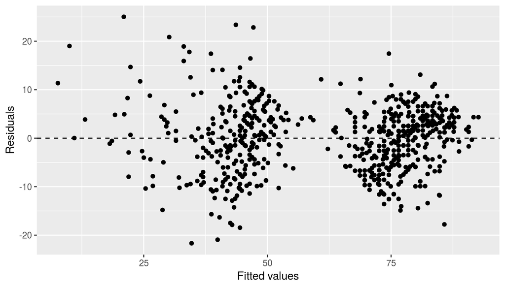

```r
ggplot(data = fit3, aes(x = .fitted, y = .resid)) +
  geom_point() +
  geom_hline(yintercept = 0, linetype = "dashed") +
  xlab("Fitted values") +
  ylab("Residuals")
```

There is clear a linear relationship between imdb rating and audience score. The linearity condition is met by our model.

Constant variance of residuals condition met, No fan shape in residuals plot.

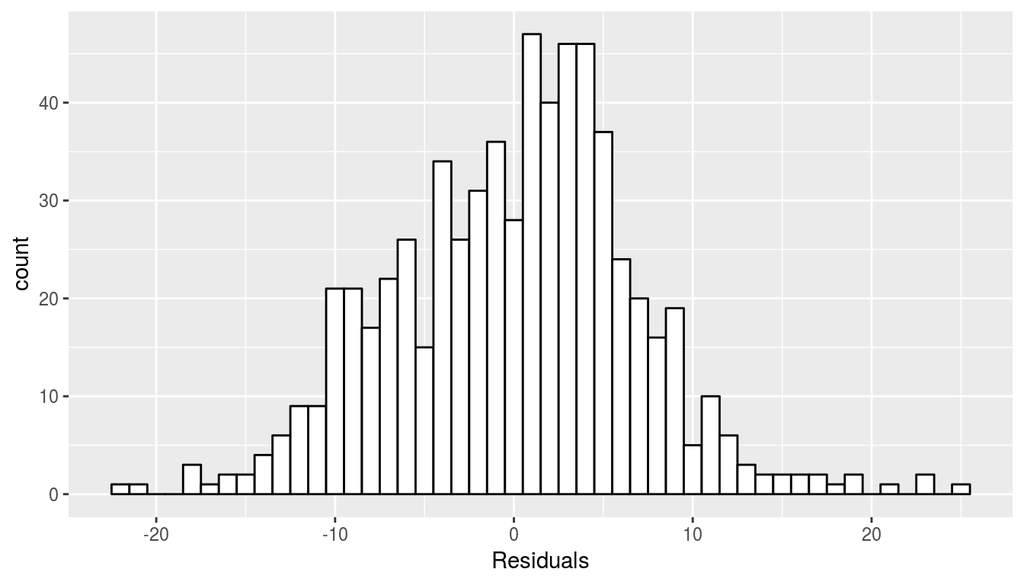

```r
ggplot(data = fit3, aes(x = .resid)) +
  geom_histogram(binwidth = 1, fill='white', color='black') +
  xlab("Residuals")
```

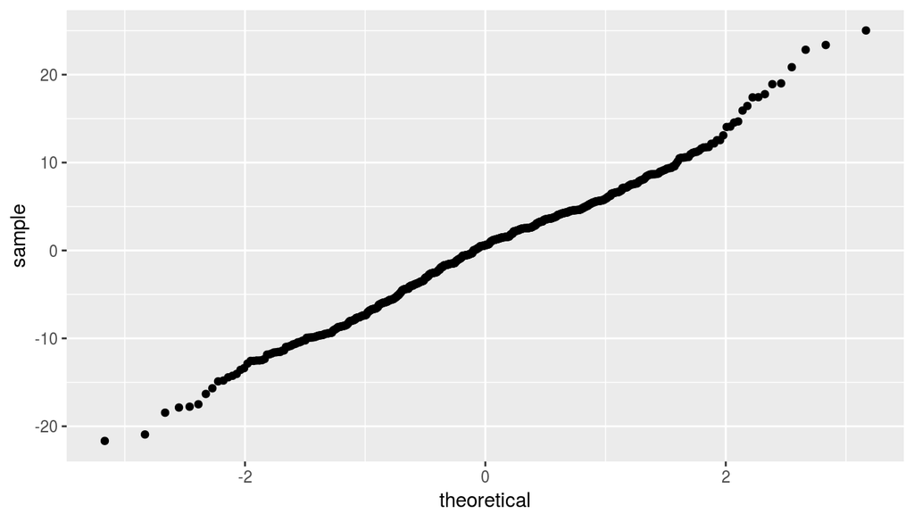

```r
ggplot(data = fit3, aes(sample = .resid)) +
  stat_qq()
```

The residuals are nearly symmetric, hence it would be appropriate to deem the the normal distribution of residuals condition met.

## Part 5: Prediction

We are going to use the model created earlier(fit3) to predict the audience score for the movie in the test set - Aliens. First we create a new dataframe for this movie.

```r
newmovie <- test %>% select(genre, imdb_rating, audience_rating)
predict(fit3, newmovie)
```

```
##        1
## 89.99899
```

The model predicts movie Aliens in the test set will have an audience score at approximate 90.

```r
predict(fit3, newmovie, interval = "prediction", level = 0.95)
```

```
##        fit      lwr     upr
## 1 89.99899 76.34498 103.653
```

Our model predicts, with 95% confidence, that the movie Aliens is expected to have an audience score between 76.34 and 103.65.

```r
test$audience_score
```

```
## [1] 94
```

The actual audience score for this movie is 94. Our prediction interval contains this value.

## Part 6: Conclusion

Our model demonstrates that it is possible to predict a movie’s popularity, as measured by audience score with only three predictors - imdb score, audience rating and genre. Movie industries can use the similar methods when producing movies that are more likely to be liked by the target audience.

However, the potential shortcoming is that our model’s predictive power is limited because the sample data is not representative. Therefore, a larger number of observations to capture more variability in the population data in our testing data set is required to have a better measure of the model’s accuracy.